# Empirical Project: Health Expenditure, Education, and Life Expectancy

2026

## 1. Motivation

Life expectancy is one of the most widely used indicators of a country’s level of development and overall well-being. It summarizes the health conditions, living standards, and socio-economic environment experienced by a population. Understanding the factors that influence life expectancy is therefore relevant not only from an economic perspective but also from a public policy perspective, as governments continuously invest resources in healthcare systems, education, and social programs with the objective of improving citizens’ quality of life.

In recent decades, substantial differences in life expectancy have persisted across countries. While developed economies often record life expectancy levels above 80 years, many developing countries still experience significantly lower values. These disparities suggest that economic resources alone may not be sufficient to explain differences in health outcomes, and that other socio-economic factors such as education, access to healthcare, nutrition, and basic public services may also play an important role.

For these reasons, this project investigates the relationship between life expectancy and two key determinants frequently highlighted in the literature: health expenditure and education. We also consider additional factors, including GDP per capita, access to clean water, and undernourishment, in order to account for differences in economic development and living conditions across countries.

Previous studies suggest that higher healthcare expenditure may contribute to improvements in life expectancy and other population health outcomes. Nixon and Ulmann (2006), for example, find evidence of a positive association between healthcare spending and health outcomes across countries. Education has also been identified as an important determinant of health and longevity. Cutler and Lleras-Muney (2006) argue that more educated individuals tend to adopt healthier lifestyles, make more informed health decisions, and enjoy better long-term health outcomes.

Building on this literature, this study investigates the relationship between health expenditure, education, and life expectancy across countries. In addition, we examine whether these relationships remain robust after controlling for other socio-economic factors such as GDP per capita, access to clean water, and undernourishment, as well as country-specific characteristics that may influence health outcomes.

The main objective of this project is therefore to assess whether health expenditure and education are significantly associated with higher life expectancy and whether these associations persist after accounting for differences in economic development and country heterogeneity.

## 2. Research Questions

The motivation for this project comes from the large differences in life expectancy observed across countries. While some countries have achieved life expectancy levels above 80 years, others still face substantially lower outcomes. Understanding which socio-economic factors are associated with these differences is important for both researchers and policymakers.

Previous studies have highlighted the importance of healthcare resources, education, and economic development in explaining population health outcomes. Building on this literature, our project investigates whether differences in health expenditure and education are associated with differences in life expectancy across countries.

### Primary Research Question (RQ1) - Health Expenditure

**What is the relationship between health expenditure per capita and life expectancy across countries, after controlling for economic development and living conditions?**

### Secondary Research Question 1 (RQ2) - Education

**Does education enrollment remain positively associated with life expectancy after controlling for health expenditure, GDP per capita, and other socio-economic factors?**

### Secondary Research Question 2 (RQ3) - Heterogeneity by Income Level

**Does the relationship between health expenditure and life expectancy differ according to a country’s level of economic development?** *In particular, we investigate whether health expenditure is more strongly associated with life expectancy in poorer countries than in richer countries.*

## 3. Specification

### 3.1 Regression Model

To answer the primary research question, we estimate the following model:

$$LifeExp_{it} = \beta_0 + \beta_1
\log(HealthExp_{it}) + \beta_2 \log(GDPpc_{it}) + \beta_3
Undernourishment_{it} + \beta_4 CleanWater_{it} +
\varepsilon_{it}$$

Where: * **LifeExp** is life expectancy at birth; * **HealthExp** is health expenditure per capita; * **GDPpc** is GDP per capita (PPP adjusted); * **Undernourishment** measures the prevalence of undernourishment; * **CleanWater** measures access to safely managed drinking water.

To address Secondary Research Question 1, we add a lagged measure of education:

$$LifeExp_{it} = \beta_0 + \beta_1
\log(HealthExp_{it}) + \beta_2 Education_{i,t-5} + \beta_3
\log(GDPpc_{it}) + \beta_4 Undernourishment_{it} + \beta_5
CleanWater_{it} + \varepsilon_{it}$$

The education variable is lagged by five years to reflect the delayed impact of education on health outcomes and to reduce potential reverse-causality concerns.

To address Secondary Research Question 2, we introduce an interaction term between health expenditure and GDP per capita:

$$LifeExp_{it} = ... + \beta_6
[\log(HealthExp_{it}) \times \log(GDPpc_{it})] +
\varepsilon_{it}$$

This interaction allows us to examine whether the association between health expenditure and life expectancy differs across levels of economic development.

### 3.2 Hypothesis Testing

- **Research Question 1 (Health Expenditure):**
  - $H_0: \beta_1 = 0$
  - $H_1: \beta_1 > 0$
  - *Expectation:* We expect health expenditure to be positively associated with life expectancy.
- **Research Question 2 (Education):**
  - $H_0: \beta_2 = 0$
  - $H_1: \beta_2 > 0$
  - *Expectation:* We expect education enrollment to be positively associated with life expectancy, even after controlling for health expenditure and economic development.
- **Research Question 3 (Interaction):**
  - $H_0: \beta_6 = 0$
  - $H_1: \beta_6 < 0$
  - *Expectation:* A negative interaction coefficient would suggest that the relationship between health expenditure and life expectancy is stronger in lower-income countries than in higher-income countries.

### 3.3 Potential Sources of Bias

- **Omitted Variable Bias:** Countries that spend more on health are often wealthier, better governed, and characterized by stronger institutions and infrastructure. These factors may independently affect life expectancy. *Strategy:* To reduce this problem, we include GDP per capita, access to clean water, and undernourishment as control variables.
- **Unobserved Country Heterogeneity:** Countries differ in many dimensions that are difficult to observe directly, such as geography, culture, institutions, and historical development. *Strategy:* To address this issue, we estimate Country Fixed Effects models, which control for all time-invariant characteristics of each country. The Hausman test strongly supports the use of Fixed Effects over Random Effects in our dataset.
- **Reverse Causality:** The relationship between education and life expectancy may suffer from reverse causality because healthier societies may also achieve better educational outcomes. *Strategy:* To partially mitigate this issue, we use a five-year lag for education, ensuring that education is measured before the corresponding life expectancy outcome.
- **Heteroskedasticity:** Cross-country data often exhibit heteroskedasticity because the variability of the error term differs substantially across countries. *Strategy:* For this reason, all hypothesis tests are conducted using heteroskedasticity-robust standard errors.

### 3.4 Assumptions

The empirical analysis assumes that, after controlling for observable characteristics and country fixed effects, the explanatory variables are not systematically correlated with unobserved factors affecting life expectancy. While the fixed-effects approach substantially reduces omitted-variable bias, the results should be interpreted primarily as evidence of association rather than definitive causal effects. Therefore, the findings identify robust relationships between health expenditure, education, and life expectancy, while acknowledging the limitations inherent in observational data.

## 4. Data and Descriptive Statistics

### 4.1 Data Sources and Sample Description

The analysis combines information from two different sources: 1. **Kaggle Dataset:** Contains information on countries’ life expectancy, prevalence of undernourishment, geographical region, and income group classification. 2. **World Development Indicators (WDI) - World Bank:** Data on Current Health Expenditure per Capita, Secondary School Enrollment Rate, Access to Clean Drinking Water, and GDP per Capita (PPP-adjusted).

The two datasets were merged using the country ISO code and year, generating a country-year panel dataset. The timeframe spans from 2000 to 2019. After merging, removing missing values, and constructing the lagged education variable, the final sample contains 1,565 observations from 105 countries.

### 4.2 Code Execution: Data Preparation

```r
#LIBRARIES
library(readxl)
library(dplyr)
library(WDI)
library(plm)
library(ggplot2)
library(modelsummary)
library(tidyr)
library(sandwich)
library(lmtest)
library(car)

setwd("/Users/sergiodilapi/Desktop/EEproj")

# 1. LOAD DATASET

df <- read_excel("life_expectancy_clean.xlsx")

df <- df %>%
  rename(
    country          = `Country Name`,
    iso              = `Country Code`,
    region           = Region,
    income_group     = IncomeGroup,
    year             = Year,
    life_exp         = `Life Expectancy World Bank`,
    undernourishment = `Prevelance of Undernourishment`
  ) %>%
  mutate(
    year             = as.numeric(year),
    life_exp         = as.numeric(life_exp),
    undernourishment = as.numeric(undernourishment)
  )

# 2. DOWNLOAD WDI VARIABLES

wdi_data <- WDI(
  country = "all",
  indicator = c(

    # Main causal variables
    health_pc        = "SH.XPD.CHEX.PC.CD",
    education_enroll = "SE.SEC.ENRR",

    # Control variables
    clean_water      = "SH.H2O.SMDW.ZS",
    gdp_pc_ppp       = "NY.GDP.PCAP.PP.KD"
  ),
  start = min(df$year, na.rm = TRUE),
  end   = max(df$year, na.rm = TRUE)
)

wdi_data <- wdi_data %>%
  rename(iso = iso3c) %>%
  select(
    iso,
    year,
    health_pc,
    education_enroll,
    clean_water,
    gdp_pc_ppp
  )

# 3. MERGE DATASETS

df <- df %>%
  left_join(wdi_data, by = c("iso", "year"))

# 4. CLEANING AND TRANSFORMATIONS

df_clean <- df %>%
  filter(
    !is.na(life_exp),

    !is.na(health_pc),
    health_pc > 0,

    !is.na(education_enroll),
    education_enroll > 0,

    !is.na(undernourishment),
    undernourishment >= 0,

    !is.na(clean_water),
    clean_water >= 0,

    !is.na(gdp_pc_ppp),
    gdp_pc_ppp > 0
  ) %>%
  mutate(
    log_health_pc = log(health_pc),
    log_gdp_pc    = log(gdp_pc_ppp)
  )

cat(
  "Clean dataset:",
  nrow(df_clean),
  "observations -",
  n_distinct(df_clean$iso),
  "countries\n"
)

# 5. CREATE LAGS

df_clean <- df_clean %>%
  arrange(iso, year) %>%
  group_by(iso) %>%
  mutate(
    education_lag5 = lag(education_enroll, 5)
  ) %>%
  ungroup() %>%
  filter(
    !is.na(education_lag5),
    !is.na(undernourishment)
  )

cat(
  "Dataset with lag:",
  nrow(df_clean),
  "observations -",
  n_distinct(df_clean$iso),
  "countries\n"
)
```

[output not shown]

### 4.3 Code Execution: Descriptive Statistics

```r
# 6. DESCRIPTIVE STATISTICS

cat("\nDESCRIPTIVE STATISTICS\n")
```

```
##
## DESCRIPTIVE STATISTICS
```

```r
print(summary(
  df_clean[, c(
    "life_exp",
    "log_health_pc",
    "education_lag5",
    "log_gdp_pc",
    "undernourishment",
    "clean_water"
  )]
))
```

```
##     life_exp     log_health_pc   education_lag5      log_gdp_pc
##  Min.   :40.37   Min.   :1.532   Min.   :  6.667   Min.   : 6.667
##  1st Qu.:68.43   1st Qu.:4.596   1st Qu.: 68.560   1st Qu.: 8.884
##  Median :74.34   Median :5.908   Median : 92.412   Median : 9.784
##  Mean   :72.18   Mean   :5.945   Mean   : 84.809   Mean   : 9.659
##  3rd Qu.:78.98   3rd Qu.:7.549   3rd Qu.:102.824   3rd Qu.:10.627
##  Max.   :84.36   Max.   :9.264   Max.   :164.080   Max.   :11.840
##  undernourishment  clean_water
##  Min.   : 2.500   Min.   :  5.283
##  1st Qu.: 2.500   1st Qu.: 44.496
##  Median : 3.700   Median : 77.768
##  Mean   : 8.068   Mean   : 67.809
##  3rd Qu.:10.500   3rd Qu.: 96.120
##  Max.   :50.700   Max.   :100.000
```

```r
cat("\nCORRELATION MATRIX:\n")
```

```
##
## CORRELATION MATRIX:
```

```r
df_clean %>%
  select(
    life_exp,
    log_health_pc,
    education_lag5,
    log_gdp_pc,
    undernourishment,
    clean_water
  ) %>%
  cor(use = "complete.obs") %>%
  round(3) %>%
  print()
```

```
##                  life_exp log_health_pc education_lag5 log_gdp_pc
## life_exp            1.000         0.792          0.788      0.820
## log_health_pc       0.792         1.000          0.832      0.942
## education_lag5      0.788         0.832          1.000      0.856
## log_gdp_pc          0.820         0.942          0.856      1.000
## undernourishment   -0.704        -0.718         -0.762     -0.771
## clean_water         0.831         0.856          0.843      0.907
##                  undernourishment clean_water
## life_exp                   -0.704       0.831
## log_health_pc              -0.718       0.856
## education_lag5             -0.762       0.843
## log_gdp_pc                 -0.771       0.907
## undernourishment            1.000      -0.759
## clean_water                -0.759       1.000
```

```r
# 7. DESCRIPTIVE TABLE

desc_stats <- data.frame(
  Variable = c(
    "Life Expectancy",
    "Log Health Expenditure",
    "Education Lag 5",
    "Log GDP per Capita",
    "Undernourishment",
    "Clean Water Access"
  ),

  Mean = c(
    mean(df_clean$life_exp, na.rm = TRUE),
    mean(df_clean$log_health_pc, na.rm = TRUE),
    mean(df_clean$education_lag5, na.rm = TRUE),
    mean(df_clean$log_gdp_pc, na.rm = TRUE),
    mean(df_clean$undernourishment, na.rm = TRUE),
    mean(df_clean$clean_water, na.rm = TRUE)
  ),

  Variance = c(
    var(df_clean$life_exp, na.rm = TRUE),
    var(df_clean$log_health_pc, na.rm = TRUE),
    var(df_clean$education_lag5, na.rm = TRUE),
    var(df_clean$log_gdp_pc, na.rm = TRUE),
    var(df_clean$undernourishment, na.rm = TRUE),
    var(df_clean$clean_water, na.rm = TRUE)
  ),

  Minimum = c(
    min(df_clean$life_exp, na.rm = TRUE),
    min(df_clean$log_health_pc, na.rm = TRUE),
    min(df_clean$education_lag5, na.rm = TRUE),
    min(df_clean$log_gdp_pc, na.rm = TRUE),
    min(df_clean$undernourishment, na.rm = TRUE),
    min(df_clean$clean_water, na.rm = TRUE)
  ),

  Maximum = c(
    max(df_clean$life_exp, na.rm = TRUE),
    max(df_clean$log_health_pc, na.rm = TRUE),
    max(df_clean$education_lag5, na.rm = TRUE),
    max(df_clean$log_gdp_pc, na.rm = TRUE),
    max(df_clean$undernourishment, na.rm = TRUE),
    max(df_clean$clean_water, na.rm = TRUE)
  )
)

print(desc_stats)
```

```
##                 Variable      Mean   Variance   Minimum    Maximum
## 1        Life Expectancy 72.183447  81.234507 40.369000  84.356341
## 2 Log Health Expenditure  5.944741   3.256332  1.531910   9.263902
## 3        Education Lag 5 84.809360 842.814011  6.666580 164.079819
## 4     Log GDP per Capita  9.658606   1.273916  6.666690  11.839910
## 5       Undernourishment  8.068243  73.647309  2.500000  50.700000
## 6     Clean Water Access 67.808953 912.594367  5.283256 100.000000
```

```r
# 8. PANEL DATA STRUCTURE

pdata <- pdata.frame(
  df_clean,
  index = c("iso", "year")
)
```

*Note: The correlation matrix reveals a strong positive correlation between GDP per capita and health expenditure (0.942), indicating that wealthier countries generally spend more on healthcare. This motivates the inclusion of GDP per capita as a control variable and provides a preliminary assessment of potential multicollinearity issues.*

## 5. Results

### 5.1 Primary Research Question: Health Expenditure and Life Expectancy

**Note on Coefficient Interpretation (Level-Log Specification):** Since the dependent variable (Life Expectancy) is measured in levels (years) and the primary independent variables (Health Expenditure and GDP per capita) are log-transformed, the estimated coefficients must be interpreted according to a level-log functional form. Specifically, a 1% increase in the independent variable is associated with an absolute increase in life expectancy equal to $\beta / 100$ years.

- **H₀:** $\beta_{health} = 0$ | **H₁:** $\beta_{health} > 0$
- **OLS Specification:** Produces a positive and statistically significant coefficient for health expenditure ($\beta = 0.893$, $p < 0.001$). We reject the null hypothesis.
- **Country Fixed Effects (FE):** The coefficient increases to 1.519 and remains highly significant ($p < 0.001$). The Hausman test strongly rejects Random Effects ($p < 0.001$), favoring the FE model. This suggests the positive relationship persists after controlling for unobserved time-invariant country characteristics.
- **Two-Way Fixed Effects (TWFE):** Produces a negative and statistically insignificant coefficient ($\beta = -0.321$, $p = 0.435$). We fail to reject the null hypothesis here.
- **Interpretation:** OLS and Country FE support the hypothesis that health expenditure is positively associated with life expectancy. The lack of significance in TWFE suggests that part of the cross-country relationship may reflect global trends affecting all countries over time. Overall, countries investing more resources in healthcare generally achieve better health outcomes.

### 5.2 Secondary Research Question 1: Education and Life Expectancy

**Note on Coefficient Interpretation (Level-Log Specification):** Since the dependent variable (Life Expectancy) is measured in levels (years) and the primary independent variables (Health Expenditure and GDP per capita) are log-transformed, the estimated coefficients must be interpreted according to a level-log functional form. Specifically, a 1% increase in the independent variable is associated with an absolute increase in life expectancy equal to $\beta / 100$ years.

- **H₀:** $\beta_{education} = 0$ | **H₁:** $\beta_{education} > 0$
- **OLS Specification (Education only):** Yields a positive and highly significant coefficient ($\beta = 0.061$, $p < 0.001$).
- **OLS (with controls):** Coefficient remains positive and significant ($\beta = 0.056$, $p < 0.001$), indicating the relationship is not solely driven by differences in income or healthcare spending.
- **Country FE & TWFE:** The result is remarkably stable in the Country FE model ($\beta = 0.056$, $p < 0.001$) and remains positive/significant at the 5% level in the TWFE specification ($\beta = 0.024$, $p = 0.048$).
- **Interpretation:** We consistently reject the null hypothesis across all specifications. Education is robustly and positively associated with life expectancy, potentially operating through healthier lifestyles, greater health awareness, and better access to information.

### 5.3 Secondary Research Question 2: Heterogeneity by Income Level

- **H₀:** $\beta_{interaction} = 0$ | **H₁:** $\beta_{interaction} < 0$
- **OLS & Country FE:** The interaction term is statistically insignificant (OLS: $p = 0.962$; FE: $p = 0.326$). We fail to reject the null hypothesis.
- **TWFE:** The interaction coefficient becomes negative and highly significant ($\beta = -0.753$, $p < 0.001$). We reject the null hypothesis.
- **Interpretation:** Suggestive evidence from the TWFE model indicates that health spending has a stronger association with life expectancy in poorer countries than in richer ones. In low-income countries, marginal resources likely finance essential, high-impact services (vaccines, primary care), whereas high-income countries already operate at high provision levels, yielding smaller marginal gains.

### 5.4 Code Execution: Regression Models and Diagnostics

```r
# 9. REGRESSION MODELS

# OLS - Health only
model_ols_health <- lm(
  life_exp ~
    log_health_pc +
    log_gdp_pc +
    undernourishment +
    clean_water,
  data = df_clean
)

# OLS - Education only
model_ols_edu <- lm(
  life_exp ~
    education_lag5 +
    log_gdp_pc +
    undernourishment +
    clean_water,
  data = df_clean
)

# OLS - Health + Education
model_ols_both <- lm(
  life_exp ~
    log_health_pc +
    education_lag5 +
    log_gdp_pc +
    undernourishment +
    clean_water,
  data = df_clean
)

# Country FE
model_fe <- plm(
  life_exp ~
    log_health_pc +
    education_lag5 +
    log_gdp_pc +
    undernourishment +
    clean_water,
  data   = pdata,
  model  = "within",
  effect = "individual"
)

# TWFE
model_fe_tw <- plm(
  life_exp ~
    log_health_pc +
    education_lag5 +
    log_gdp_pc +
    undernourishment +
    clean_water,
  data   = pdata,
  model  = "within",
  effect = "twoways"
)

# RANDOM EFFECTS MODEL
model_re <- plm(
  life_exp ~
    log_health_pc +
    education_lag5 +
    log_gdp_pc +
    undernourishment +
    clean_water,
  data  = pdata,
  model = "random"
)

# HAUSMAN TEST
cat("\nHAUSMAN TEST\n")
```

```
##
## HAUSMAN TEST
```

```r
hausman_test <- phtest(
  model_fe,
  model_re
)
print(hausman_test)
```

```
##
##  Hausman Test
##
## data:  life_exp ~ log_health_pc + education_lag5 + log_gdp_pc + undernourishment +  ...
## chisq = 27.179, df = 5, p-value = 5.264e-05
## alternative hypothesis: one model is inconsistent
```

```r
# 10. ROBUST STANDARD ERRORS
vcov_ols_health <- vcovHC(model_ols_health, type = "HC1")
vcov_ols_edu    <- vcovHC(model_ols_edu, type = "HC1")
vcov_ols_both   <- vcovHC(model_ols_both, type = "HC1")

vcov_fe <- vcovHC(
  model_fe,
  type = "HC1",
  cluster = "group"
)

vcov_fe_tw <- vcovHC(
  model_fe_tw,
  type = "HC1",
  cluster = "group"
)

# 11. REGRESSION TABLE - CONSOLE
coef_map <- c(
  "log_health_pc"    = "Log Health Exp. per capita",
  "education_lag5"   = "Secondary Enrollment lag 5 (%)",
  "log_gdp_pc"       = "Log GDP per capita (PPP)",
  "undernourishment" = "Undernourishment (%)",
  "clean_water"      = "Clean Water Access (%)"
)

modelsummary(
  list(
    "Only Health"        = model_ols_health,
    "Only Education"     = model_ols_edu,
    "Health + Education" = model_ols_both,
    "Country FE"         = model_fe,
    "TWFE"               = model_fe_tw
  ),
  coef_map = coef_map,
  stars = c(
    "*"   = .1,
    "**"  = .05,
    "***" = .01
  ),
  gof_omit = "AIC|BIC|Log|F$",
  vcov = list(
    vcov_ols_health,
    vcov_ols_edu,
    vcov_ols_both,
    vcov_fe,
    vcov_fe_tw
  ),
  output = "markdown"
)
```

Only Health

Only Education

Health + Education

Country FE

TWFE

Log Health Exp. per capita

0.893***

0.674***

1.519***

-0.321

(0.214)

(0.214)

(0.318)

(0.411)

Secondary Enrollment lag 5 (%)

0.061***

0.056***

0.056***

0.024**

(0.008)

(0.008)

(0.014)

(0.012)

Log GDP per capita (PPP)

1.207***

1.902***

0.935**

1.848**

0.849

(0.447)

(0.272)

(0.423)

(0.891)

(0.923)

Undernourishment (%)

-0.120***

-0.073**

-0.080**

0.011

-0.034

(0.033)

(0.034)

(0.035)

(0.047)

(0.045)

Clean Water Access (%)

0.136***

0.119***

0.120***

0.109***

0.055**

(0.012)

(0.011)

(0.011)

(0.026)

(0.022)

Num.Obs.

1565

1565

1565

1565

1565

R2

0.724

0.729

0.731

0.590

0.078

R2 Adj.

0.723

0.728

0.730

0.559

-0.004

RMSE

4.73

4.69

4.67

1.19

0.98

Std.Errors

Custom

Custom

Custom

Custom

Custom

- p < 0.1, ** p < 0.05, *** p < 0.01

```r
# 12. R-SQUARED
cat("\nR-SQUARED\n")
```

```
##
## R-SQUARED
```

```r
ols_sum <- summary(model_ols_both)
cat("OLS R2:", round(ols_sum$r.squared, 3), "\n")
```

```
## OLS R2: 0.731
```

```r
cat("OLS Adjusted R2:", round(ols_sum$adj.r.squared, 3), "\n")
```

```
## OLS Adjusted R2: 0.73
```

```r
fe_sum <- summary(model_fe)
cat("Country FE Within R2:", round(fe_sum$r.squared["rsq"], 3), "\n")
```

```
## Country FE Within R2: 0.59
```

```r
cat("Country FE Adjusted R2:", round(fe_sum$r.squared["adjrsq"], 3), "\n")
```

```
## Country FE Adjusted R2: 0.559
```

```r
fe_tw_sum <- summary(model_fe_tw)
cat("TWFE Within R2:", round(fe_tw_sum$r.squared["rsq"], 3), "\n")
```

```
## TWFE Within R2: 0.078
```

```r
cat("TWFE Adjusted Within R2:", round(fe_tw_sum$r.squared["adjrsq"], 3), "\n")
```

```
## TWFE Adjusted Within R2: -0.004
```

```r
# 13. GDP ROBUSTNESS CHECK (OLS)
model_ols_no_gdp <- lm(
  life_exp ~
    log_health_pc +
    education_lag5 +
    undernourishment +
    clean_water,
  data = df_clean
)

model_ols_with_gdp <- lm(
  life_exp ~
    log_health_pc +
    education_lag5 +
    log_gdp_pc +
    undernourishment +
    clean_water,
  data = df_clean
)

vcov_ols_no_gdp <- vcovHC(model_ols_no_gdp, type = "HC1")
vcov_ols_with_gdp <- vcovHC(model_ols_with_gdp, type = "HC1")

cat("\nGDP ROBUSTNESS CHECK (OLS)\n\n")
```

```
##
## GDP ROBUSTNESS CHECK (OLS)
```

```r
modelsummary(
  list(
    "Without GDP" = model_ols_no_gdp,
    "With GDP"    = model_ols_with_gdp
  ),
  coef_map = coef_map,
  stars = c("*" = .1, "**" = .05, "***" = .01),
  vcov = list(vcov_ols_no_gdp, vcov_ols_with_gdp),
  gof_omit = "AIC|BIC|Log|F$",
  output = "markdown"
)
```

Without GDP

With GDP

Log Health Exp. per capita

1.009***

0.674***

(0.136)

(0.214)

Secondary Enrollment lag 5 (%)

0.058***

0.056***

(0.008)

(0.008)

Log GDP per capita (PPP)

0.935**

(0.423)

Undernourishment (%)

-0.090***

-0.080**

(0.034)

(0.035)

Clean Water Access (%)

0.130***

0.120***

(0.010)

(0.011)

Num.Obs.

1565

1565

R2

0.730

0.731

R2 Adj.

0.729

0.730

RMSE

4.68

4.67

Std.Errors

Custom

Custom

- p < 0.1, ** p < 0.05, *** p < 0.01

```r
# BIAS

# 4. MULTICOLLINEARITY CHECK
cat("\nVIF CHECK\n")
```

```
##
## VIF CHECK
```

```r
mod_vif <- lm(
  life_exp ~
    log_health_pc +
    education_lag5 +
    log_gdp_pc +
    undernourishment +
    clean_water,
  data = df_clean
)
print(vif(mod_vif))
```

```
##    log_health_pc   education_lag5       log_gdp_pc undernourishment
##         9.181372         4.555389        14.375381         2.808017
##      clean_water
##         6.353627
```

```r
# 5. HAUSMAN TEST (Repeated)
model_re <- plm(
  life_exp ~
    log_health_pc +
    education_lag5 +
    log_gdp_pc +
    undernourishment +
    clean_water,
  data  = pdata,
  model = "random"
)
cat("\nHAUSMAN TEST\n")
```

```
##
## HAUSMAN TEST
```

```r
hausman_test <- phtest(model_fe, model_re)
print(hausman_test)
```

```
##
##  Hausman Test
##
## data:  life_exp ~ log_health_pc + education_lag5 + log_gdp_pc + undernourishment +  ...
## chisq = 27.179, df = 5, p-value = 5.264e-05
## alternative hypothesis: one model is inconsistent
```

```r
# 6. HETEROSKEDASTICITY TEST
bptest(model_ols_both)
```

```
##
##  studentized Breusch-Pagan test
##
## data:  model_ols_both
## BP = 184.31, df = 5, p-value < 2.2e-16
```

```r
# 7. SERIAL CORRELATION TEST (?)
pbgtest(model_fe)
```

```
##
##  Breusch-Godfrey/Wooldridge test for serial correlation in panel models
##
## data:  life_exp ~ log_health_pc + education_lag5 + log_gdp_pc + undernourishment +  ...
## chisq = 889.16, df = 1, p-value < 2.2e-16
## alternative hypothesis: serial correlation in idiosyncratic errors
```

### 5.5 Code Execution: Hypothesis Testing (RQ1, RQ2, RQ3)

```r
# 14. RESEARCH QUESTION

# MODELS AND VCOV FOR RQ1
model_rq1_ols  <- model_ols_health
model_rq1_fe   <- model_fe
model_rq1_twfe <- model_fe_tw

vcov_rq1_ols   <- vcov_ols_health
vcov_rq1_fe    <- vcov_fe
vcov_rq1_twfe  <- vcov_fe_tw

# MODELS AND VCOV FOR RQ2
model_rq2_ols      <- model_ols_edu
model_rq2_ols_both <- model_ols_both
model_rq2_fe       <- model_fe
model_rq2_twfe     <- model_fe_tw

vcov_rq2_ols       <- vcov_ols_edu
vcov_rq2_ols_both  <- vcov_ols_both
vcov_rq2_fe        <- vcov_fe
vcov_rq2_twfe      <- vcov_fe_tw

# MODELS AND VCOV FOR RQ3
df_clean <- df_clean %>%
  mutate(
    log_gdp_pc_centered = log_gdp_pc - mean(log_gdp_pc, na.rm = TRUE)
  )

pdata <- pdata.frame(df_clean, index = c("iso", "year"))

model_rq3_ols <- lm(
  life_exp ~
    log_health_pc +
    log_gdp_pc_centered +
    log_health_pc:log_gdp_pc_centered +
    education_lag5 +
    undernourishment +
    clean_water,
  data = df_clean
)

model_rq3_fe <- plm(
  life_exp ~
    log_health_pc +
    log_gdp_pc_centered +
    log_health_pc:log_gdp_pc_centered +
    education_lag5 +
    undernourishment +
    clean_water,
  data   = pdata,
  model  = "within",
  effect = "individual"
)

model_rq3_twfe <- plm(
  life_exp ~
    log_health_pc +
    log_gdp_pc_centered +
    log_health_pc:log_gdp_pc_centered +
    education_lag5 +
    undernourishment +
    clean_water,
  data   = pdata,
  model  = "within",
  effect = "twoways"
)

vcov_rq3_ols  <- vcovHC(model_rq3_ols,  type = "HC1")
vcov_rq3_fe   <- vcovHC(model_rq3_fe,   type = "HC1", cluster = "group")
vcov_rq3_twfe <- vcovHC(model_rq3_twfe, type = "HC1", cluster = "group")

# RQ1 - HEALTH EXPENDITURE
print("RQ1 - Health Expenditure")
```

```
## [1] "RQ1 - Health Expenditure"
```

```r
print("H0: beta_health = 0")
```

```
## [1] "H0: beta_health = 0"
```

```r
print("H1: beta_health > 0")
```

```
## [1] "H1: beta_health > 0"
```

```r
print("OLS:")
```

```
## [1] "OLS:"
```

```r
print(coeftest(model_rq1_ols,  vcov = vcov_rq1_ols))
```

```
##
## t test of coefficients:
##
##                   Estimate Std. Error t value  Pr(>|t|)
## (Intercept)      46.986468   3.144502 14.9424 < 2.2e-16 ***
## log_health_pc     0.893402   0.214277  4.1694 3.222e-05 ***
## log_gdp_pc        1.206922   0.446591  2.7025  0.006956 **
## undernourishment -0.119860   0.032625 -3.6739  0.000247 ***
## clean_water       0.135614   0.012130 11.1801 < 2.2e-16 ***
## ---
## Signif. codes:  0 '***' 0.001 '**' 0.01 '*' 0.05 '.' 0.1 ' ' 1
```

```r
print("Country FE:")
```

```
## [1] "Country FE:"
```

```r
print(coeftest(model_rq1_fe,   vcov = vcov_rq1_fe))
```

```
##
## t test of coefficients:
##
##                  Estimate Std. Error t value  Pr(>|t|)
## log_health_pc    1.518703   0.318379  4.7701 2.026e-06 ***
## education_lag5   0.055857   0.014219  3.9283 8.956e-05 ***
## log_gdp_pc       1.847685   0.891117  2.0734   0.03831 *
## undernourishment 0.010841   0.047424  0.2286   0.81921
## clean_water      0.109420   0.026081  4.1955 2.888e-05 ***
## ---
## Signif. codes:  0 '***' 0.001 '**' 0.01 '*' 0.05 '.' 0.1 ' ' 1
```

```r
print("TWFE:")
```

```
## [1] "TWFE:"
```

```r
print(coeftest(model_rq1_twfe, vcov = vcov_rq1_twfe))
```

```
##
## t test of coefficients:
##
##                   Estimate Std. Error t value Pr(>|t|)
## log_health_pc    -0.321085   0.411239 -0.7808  0.43506
## education_lag5    0.023716   0.011982  1.9793  0.04797 *
## log_gdp_pc        0.848708   0.922913  0.9196  0.35794
## undernourishment -0.034134   0.045210 -0.7550  0.45036
## clean_water       0.054555   0.021941  2.4865  0.01301 *
## ---
## Signif. codes:  0 '***' 0.001 '**' 0.01 '*' 0.05 '.' 0.1 ' ' 1
```

```r
# RQ2 - EDUCATION
print("RQ2 - Education Enrollment")
```

```
## [1] "RQ2 - Education Enrollment"
```

```r
print("H0: beta_education = 0")
```

```
## [1] "H0: beta_education = 0"
```

```r
print("H1: beta_education > 0")
```

```
## [1] "H1: beta_education > 0"
```

```r
print("OLS - Solo Education:")
```

```
## [1] "OLS - Solo Education:"
```

```r
print(coeftest(model_rq2_ols,      vcov = vcov_rq2_ols))
```

```
##
## t test of coefficients:
##
##                    Estimate Std. Error t value  Pr(>|t|)
## (Intercept)      41.1985873  2.0488205 20.1084 < 2.2e-16 ***
## education_lag5    0.0609072  0.0082556  7.3777 2.606e-13 ***
## log_gdp_pc        1.9015554  0.2718083  6.9959 3.897e-12 ***
## undernourishment -0.0727819  0.0342005 -2.1281   0.03349 *
## clean_water       0.1185715  0.0106957 11.0859 < 2.2e-16 ***
## ---
## Signif. codes:  0 '***' 0.001 '**' 0.01 '*' 0.05 '.' 0.1 ' ' 1
```

```r
print("OLS - Health + Education:")
```

```
## [1] "OLS - Health + Education:"
```

```r
print(coeftest(model_rq2_ols_both, vcov = vcov_rq2_ols_both))
```

```
##
## t test of coefficients:
##
##                   Estimate Std. Error t value  Pr(>|t|)
## (Intercept)      46.950215   3.009701 15.5996 < 2.2e-16 ***
## log_health_pc     0.674251   0.213531  3.1576  0.001621 **
## education_lag5    0.055834   0.008414  6.6359 4.438e-11 ***
## log_gdp_pc        0.934752   0.423367  2.2079  0.027396 *
## undernourishment -0.079628   0.034539 -2.3054  0.021272 *
## clean_water       0.119509   0.010727 11.1404 < 2.2e-16 ***
## ---
## Signif. codes:  0 '***' 0.001 '**' 0.01 '*' 0.05 '.' 0.1 ' ' 1
```

```r
print("Country FE:")
```

```
## [1] "Country FE:"
```

```r
print(coeftest(model_rq2_fe,       vcov = vcov_rq2_fe))
```

```
##
## t test of coefficients:
##
##                  Estimate Std. Error t value  Pr(>|t|)
## log_health_pc    1.518703   0.318379  4.7701 2.026e-06 ***
## education_lag5   0.055857   0.014219  3.9283 8.956e-05 ***
## log_gdp_pc       1.847685   0.891117  2.0734   0.03831 *
## undernourishment 0.010841   0.047424  0.2286   0.81921
## clean_water      0.109420   0.026081  4.1955 2.888e-05 ***
## ---
## Signif. codes:  0 '***' 0.001 '**' 0.01 '*' 0.05 '.' 0.1 ' ' 1
```

```r
print("TWFE:")
```

```
## [1] "TWFE:"
```

```r
print(coeftest(model_rq2_twfe,     vcov = vcov_rq2_twfe))
```

```
##
## t test of coefficients:
##
##                   Estimate Std. Error t value Pr(>|t|)
## log_health_pc    -0.321085   0.411239 -0.7808  0.43506
## education_lag5    0.023716   0.011982  1.9793  0.04797 *
## log_gdp_pc        0.848708   0.922913  0.9196  0.35794
## undernourishment -0.034134   0.045210 -0.7550  0.45036
## clean_water       0.054555   0.021941  2.4865  0.01301 *
## ---
## Signif. codes:  0 '***' 0.001 '**' 0.01 '*' 0.05 '.' 0.1 ' ' 1
```

```r
# RQ3 - INTERACTION HEALTH x GDP
print("RQ3 - Heterogeneity: Health x GDP Interaction")
```

```
## [1] "RQ3 - Heterogeneity: Health x GDP Interaction"
```

```r
print("H0: beta_interaction = 0")
```

```
## [1] "H0: beta_interaction = 0"
```

```r
print("H1: beta_interaction < 0")
```

```
## [1] "H1: beta_interaction < 0"
```

```r
print("OLS:")
```

```
## [1] "OLS:"
```

```r
print(coeftest(model_rq3_ols,  vcov = vcov_rq3_ols))
```

```
##
## t test of coefficients:
##
##                                     Estimate Std. Error t value  Pr(>|t|)
## (Intercept)                       56.0013017  1.7058714 32.8286 < 2.2e-16 ***
## log_health_pc                      0.6689509  0.2634028  2.5397   0.01119 *
## log_gdp_pc_centered                0.9112410  0.6719177  1.3562   0.17524
## education_lag5                     0.0559312  0.0086430  6.4713 1.298e-10 ***
## undernourishment                  -0.0803828  0.0414355 -1.9399   0.05257 .
## clean_water                        0.1194721  0.0105664 11.3068 < 2.2e-16 ***
## log_health_pc:log_gdp_pc_centered  0.0047914  0.0994631  0.0482   0.96159
## ---
## Signif. codes:  0 '***' 0.001 '**' 0.01 '*' 0.05 '.' 0.1 ' ' 1
```

```r
print("Country FE:")
```

```
## [1] "Country FE:"
```

```r
print(coeftest(model_rq3_fe,   vcov = vcov_rq3_fe))
```

```
##
## t test of coefficients:
##
##                                    Estimate Std. Error t value  Pr(>|t|)
## log_health_pc                      1.548457   0.330643  4.6832 3.088e-06 ***
## log_gdp_pc_centered                2.939868   1.377811  2.1337  0.033032 *
## education_lag5                     0.053528   0.014432  3.7089  0.000216 ***
## undernourishment                   0.033459   0.044288  0.7555  0.450075
## clean_water                        0.105729   0.024922  4.2424 2.351e-05 ***
## log_health_pc:log_gdp_pc_centered -0.216188   0.220016 -0.9826  0.325968
## ---
## Signif. codes:  0 '***' 0.001 '**' 0.01 '*' 0.05 '.' 0.1 ' ' 1
```

```r
print("TWFE:")
```

```
## [1] "TWFE:"
```

```r
print(coeftest(model_rq3_twfe, vcov = vcov_rq3_twfe))
```

```
##
## t test of coefficients:
##
##                                     Estimate Std. Error t value  Pr(>|t|)
## log_health_pc                     -0.6761159  0.4040764 -1.6732 0.0944983 .
## log_gdp_pc_centered                4.4301497  1.2180170  3.6372 0.0002854 ***
## education_lag5                     0.0096283  0.0117706  0.8180 0.4134935
## undernourishment                   0.0342884  0.0339388  1.0103 0.3125211
## clean_water                        0.0310893  0.0215576  1.4422 0.1494773
## log_health_pc:log_gdp_pc_centered -0.7525729  0.2170817 -3.4668 0.0005423 ***
## ---
## Signif. codes:  0 '***' 0.001 '**' 0.01 '*' 0.05 '.' 0.1 ' ' 1
```

```r
# ============================================================
# SUMMARY TABLE - HYPOTHESIS TESTING
# ============================================================
print("=================================================")
```

```
## [1] "================================================="
```

```r
print("SUMMARY - HYPOTHESIS TESTING")
```

```
## [1] "SUMMARY - HYPOTHESIS TESTING"
```

```r
print("=================================================")
```

```
## [1] "================================================="
```

```r
summary_ht <- data.frame(
  RQ = c(
    "RQ1 - Health",
    "RQ1 - Health",
    "RQ1 - Health",
    "RQ2 - Education",
    "RQ2 - Education",
    "RQ2 - Education",
    "RQ2 - Education",
    "RQ3 - Interaction",
    "RQ3 - Interaction",
    "RQ3 - Interaction"
  ),
  Model = c(
    "OLS", "Country FE", "TWFE",
    "OLS Solo", "OLS Both", "Country FE", "TWFE",
    "OLS", "Country FE", "TWFE"
  ),
  Coefficient = c(
    coef(model_rq1_ols)["log_health_pc"],
    coef(model_rq1_fe)["log_health_pc"],
    coef(model_rq1_twfe)["log_health_pc"],
    coef(model_rq2_ols)["education_lag5"],
    coef(model_rq2_ols_both)["education_lag5"],
    coef(model_rq2_fe)["education_lag5"],
    coef(model_rq2_twfe)["education_lag5"],
    coef(model_rq3_ols)["log_health_pc:log_gdp_pc_centered"],
    coef(model_rq3_fe)["log_health_pc:log_gdp_pc_centered"],
    coef(model_rq3_twfe)["log_health_pc:log_gdp_pc_centered"]
  ),
  P_value = c(
    coeftest(model_rq1_ols,      vcov = vcov_rq1_ols) ["log_health_pc", 4],
    coeftest(model_rq1_fe,       vcov = vcov_rq1_fe)  ["log_health_pc", 4],
    coeftest(model_rq1_twfe,     vcov = vcov_rq1_twfe)["log_health_pc", 4],
    coeftest(model_rq2_ols,      vcov = vcov_rq2_ols)     ["education_lag5", 4],
    coeftest(model_rq2_ols_both, vcov = vcov_rq2_ols_both)["education_lag5", 4],
    coeftest(model_rq2_fe,       vcov = vcov_rq2_fe)      ["education_lag5", 4],
    coeftest(model_rq2_twfe,     vcov = vcov_rq2_twfe)    ["education_lag5", 4],
    coeftest(model_rq3_ols,  vcov = vcov_rq3_ols) ["log_health_pc:log_gdp_pc_centered", 4],
    coeftest(model_rq3_fe,   vcov = vcov_rq3_fe)  ["log_health_pc:log_gdp_pc_centered", 4],
    coeftest(model_rq3_twfe, vcov = vcov_rq3_twfe)["log_health_pc:log_gdp_pc_centered", 4]
  )
)

# Arrotonda e aggiungi colonna decisione
summary_ht$Coefficient <- round(summary_ht$Coefficient, 3)
summary_ht$P_value     <- round(summary_ht$P_value, 4)
summary_ht$Decision    <- ifelse(
  summary_ht$P_value < 0.05,
  "Reject H0 **",
  ifelse(summary_ht$P_value < 0.1,
         "Reject H0 *",
         "Fail to Reject H0")
)

print(summary_ht)
```

```
##                   RQ      Model Coefficient P_value          Decision
## 1       RQ1 - Health        OLS       0.893  0.0000      Reject H0 **
## 2       RQ1 - Health Country FE       1.519  0.0000      Reject H0 **
## 3       RQ1 - Health       TWFE      -0.321  0.4351 Fail to Reject H0
## 4    RQ2 - Education   OLS Solo       0.061  0.0000      Reject H0 **
## 5    RQ2 - Education   OLS Both       0.056  0.0000      Reject H0 **
## 6    RQ2 - Education Country FE       0.056  0.0001      Reject H0 **
## 7    RQ2 - Education       TWFE       0.024  0.0480      Reject H0 **
## 8  RQ3 - Interaction        OLS       0.005  0.9616 Fail to Reject H0
## 9  RQ3 - Interaction Country FE      -0.216  0.3260 Fail to Reject H0
## 10 RQ3 - Interaction       TWFE      -0.753  0.0005      Reject H0 **
```

## 6. Visualizations

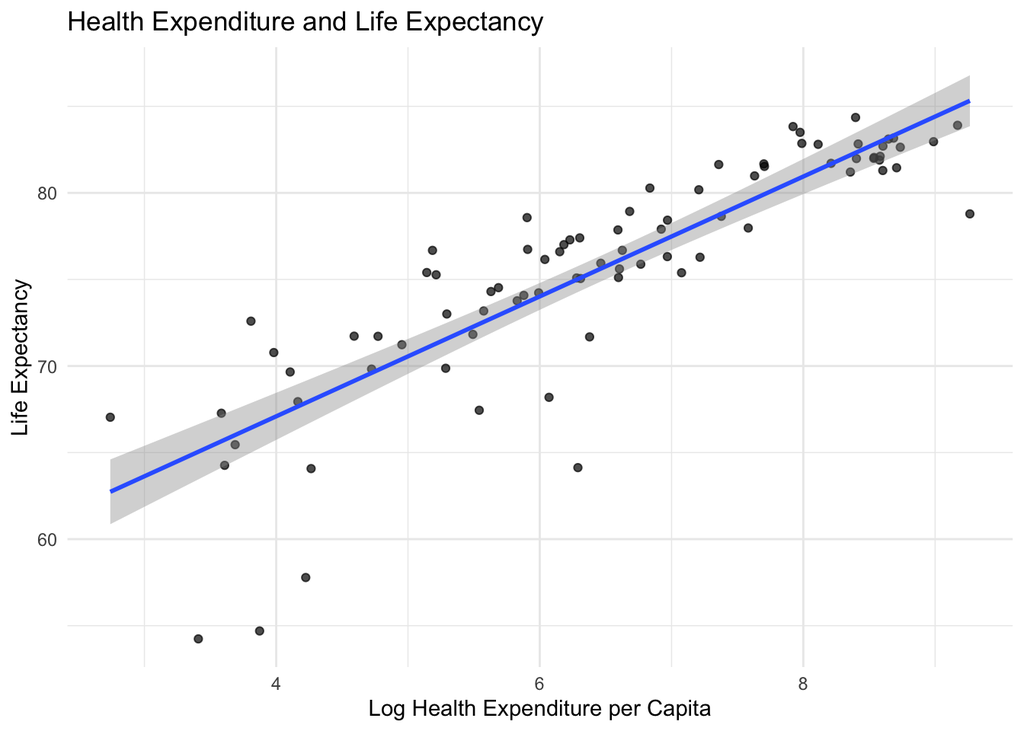

```r
# 15. GRAPHS

# SCATTERPLOT HEALTH EXPENDITURE AND LIFE EXPECTANCY 2019
ggplot(
  df_clean %>% filter(year == 2019),
  aes(
    x = log_health_pc,
    y = life_exp
  )
) +
  geom_point(alpha = 0.7) +
  geom_smooth(method = "lm", se = TRUE) +
  labs(
    title = "Health Expenditure and Life Expectancy",
    x = "Log Health Expenditure per Capita",
    y = "Life Expectancy"
  ) +
  theme_minimal()
```

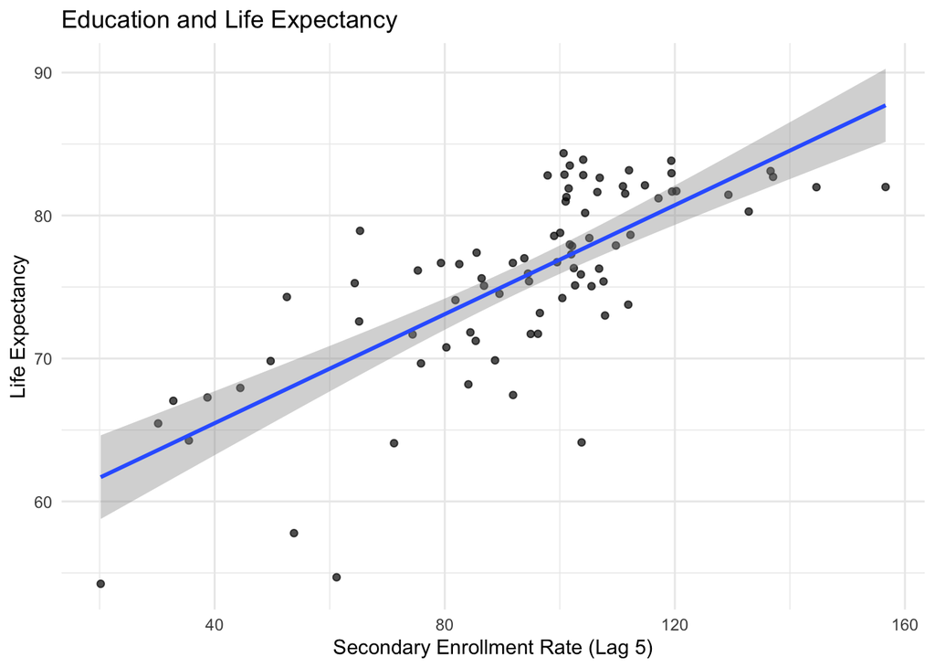

```r
# SCATTERPLOT EDUCATION AND LIFE EXPECTANCY 2019
ggplot(
  df_clean %>% filter(year == 2019),
  aes(
    x = education_lag5,
    y = life_exp
  )
) +
  geom_point(alpha = 0.7) +
  geom_smooth(method = "lm", se = TRUE) +
  labs(
    title = "Education and Life Expectancy",
    x = "Secondary Enrollment Rate (Lag 5)",
    y = "Life Expectancy"
  ) +
  theme_minimal()
```

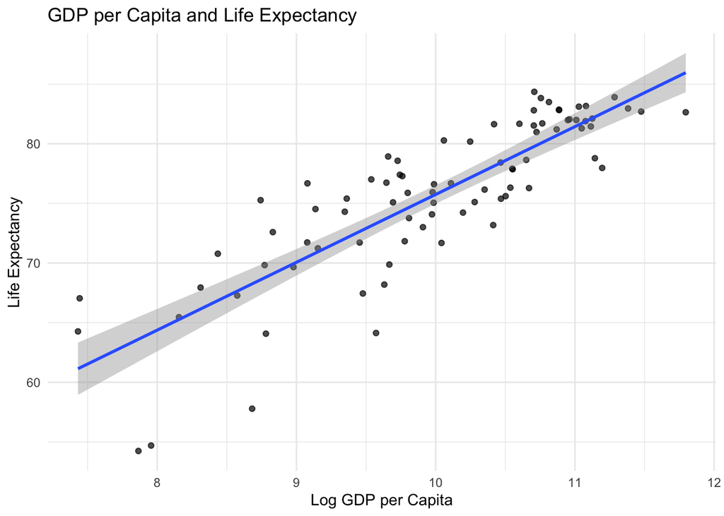

```r
# SCATTERPLOT GDP PER CAPITA AND LIFE EXPECTANCY
ggplot(
  df_clean %>% filter(year == 2019),
  aes(
    x = log_gdp_pc,
    y = life_exp
  )
) +
  geom_point(alpha = 0.7) +
  geom_smooth(method = "lm", se = TRUE) +
  labs(
    title = "GDP per Capita and Life Expectancy",
    x = "Log GDP per Capita",
    y = "Life Expectancy"
  ) +
  theme_minimal()
```

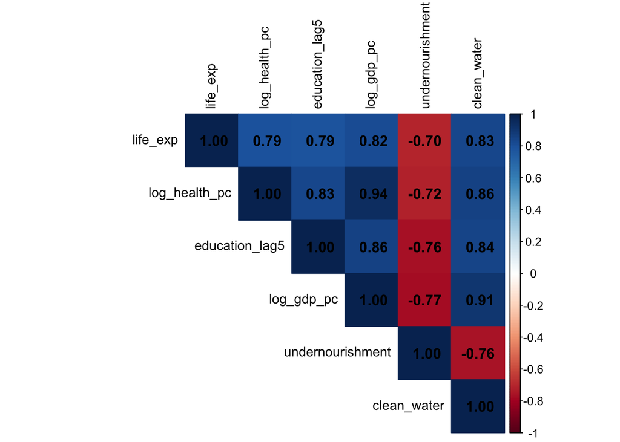

```r
# CORRELATION HEATMAP
library(corrplot)

corr_matrix <- df_clean %>%
  select(
    life_exp,
    log_health_pc,
    education_lag5,
    log_gdp_pc,
    undernourishment,
    clean_water
  ) %>%
  cor(use = "complete.obs")

corrplot(
  corr_matrix,
  method = "color",
  type = "upper",
  tl.col = "black",
  tl.cex = 0.9,
  addCoef.col = "black"
)
```

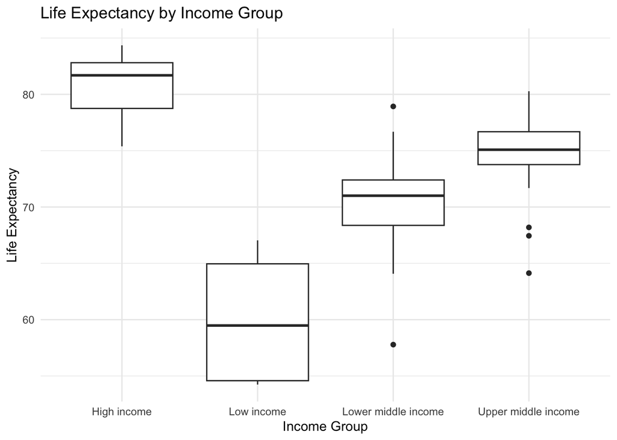

```r
# LIFE EXPECTANCY PER INCOME GROUP
ggplot(
  df_clean %>% filter(year == 2019),
  aes(
    x = income_group,
    y = life_exp
  )
) +
  geom_boxplot() +
  labs(
    title = "Life Expectancy by Income Group",
    x = "Income Group",
    y = "Life Expectancy"
  ) +
  theme_minimal()
```

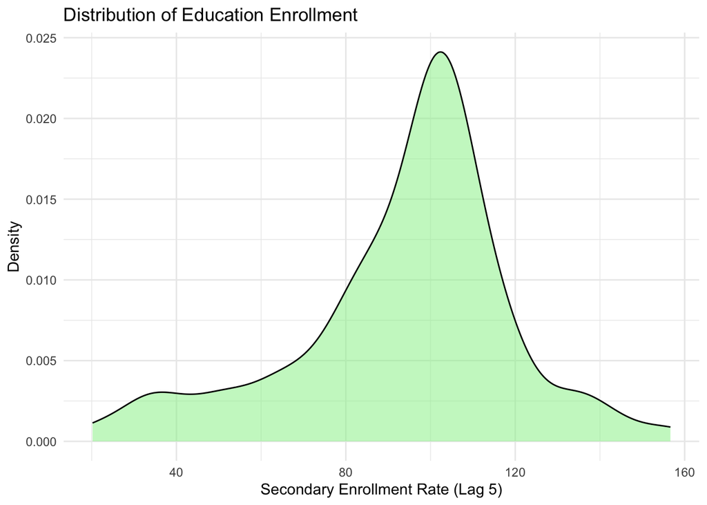

```r
# GRAFICI SULLE DENSITY
ggplot(
  df_clean %>% filter(year == 2019),
  aes(x = education_lag5)
) +
  geom_density(fill = "lightgreen", alpha = 0.5) +
  labs(
    title = "Distribution of Education Enrollment",
    x = "Secondary Enrollment Rate (Lag 5)",
    y = "Density"
  ) +
  theme_minimal()
```

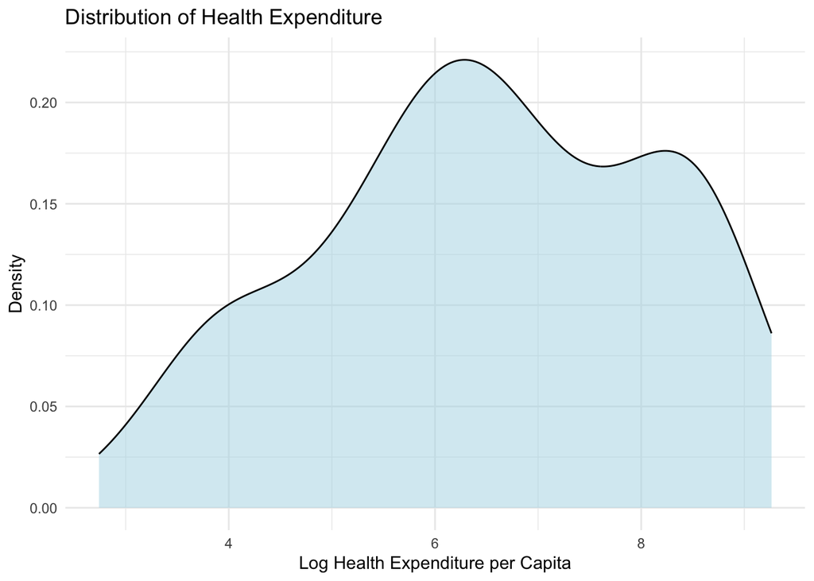

```r
ggplot(
  df_clean %>% filter(year == 2019),
  aes(x = log_health_pc)
) +
  geom_density(fill = "lightblue", alpha = 0.5) +
  labs(
    title = "Distribution of Health Expenditure",
    x = "Log Health Expenditure per Capita",
    y = "Density"
  ) +
  theme_minimal()
```

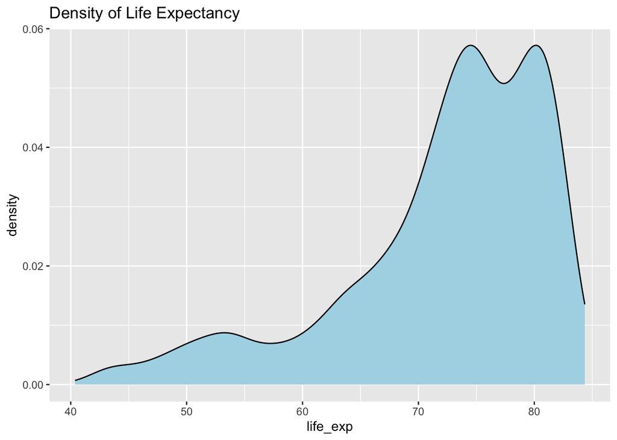

```r
ggplot(df_clean,
       aes(x = life_exp)) +
  geom_density(fill = "lightblue") +
  labs(
    title = "Density of Life Expectancy"
  )
```

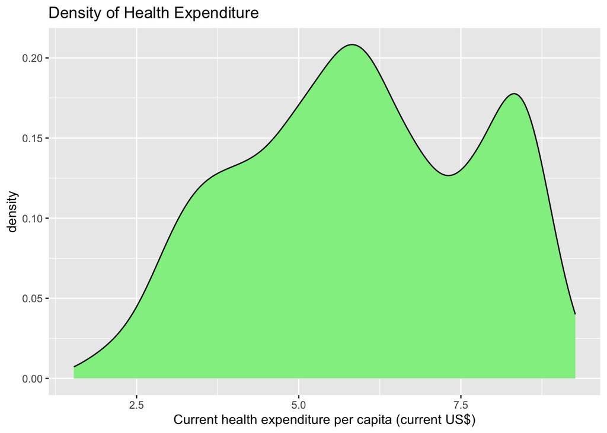

```r
ggplot(df_clean,
       aes(x = log_health_pc)) +
  geom_density(fill = "lightgreen") +
  labs(
    title = "Density of Health Expenditure"
  )
```

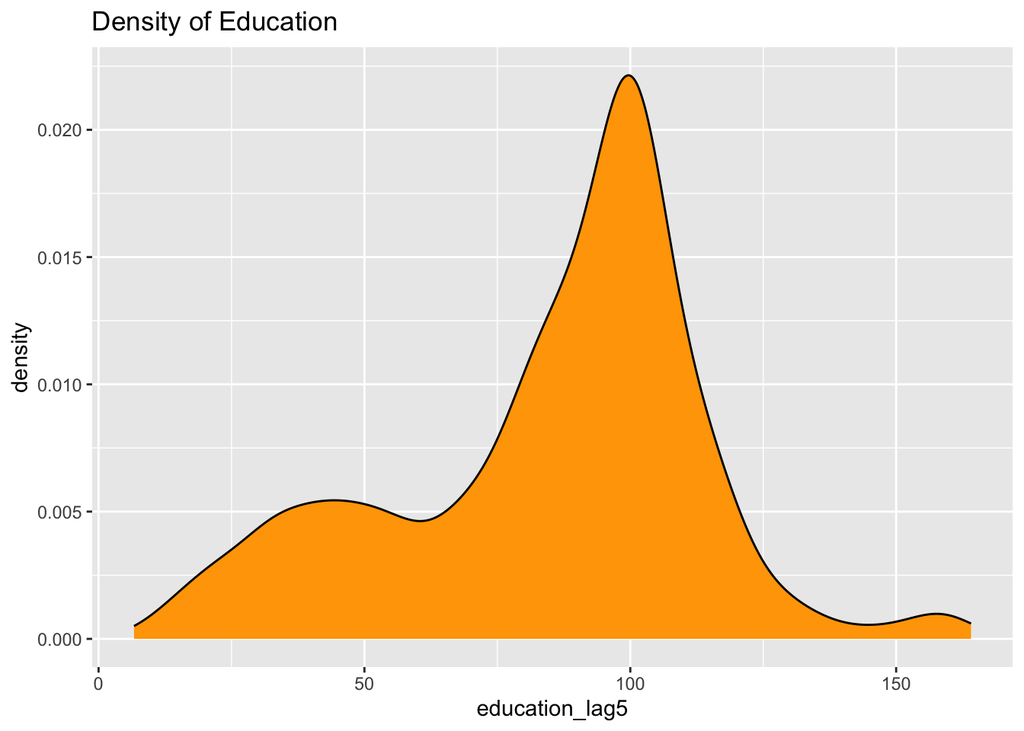

```r
ggplot(df_clean,
       aes(x = education_lag5)) +
  geom_density(fill = "orange") +
  labs(
    title = "Density of Education"
  )
```

```r
# LIFE EXPECTANCY OVER TIME ACROSS SELECTED COUNTRIES
selected_countries <- c(
  "ITA",  # Italy
  "USA",  # United States
  "DEU",  # Germany
  "CHN",  # China
  "IND",  # India
  "GHA"   # Ghana
)

# Keep only selected countries
life_plot <- df_clean %>%
  filter(iso %in% selected_countries)

# Check data coverage
life_plot %>%
  group_by(country) %>%
  summarise(
    first_year = min(year),
    last_year = max(year),
    observations = n()
  ) %>%
  arrange(country) %>%
  print()
```

```
## # A tibble: 5 × 4
##   country       first_year last_year observations
##   <chr>              <dbl>     <dbl>        <int>
## 1 Germany             2001      2019           19
## 2 Ghana               2001      2019           18
## 3 India               2001      2019           19
## 4 Italy               2001      2019           19
## 5 United States       2005      2019            8
```

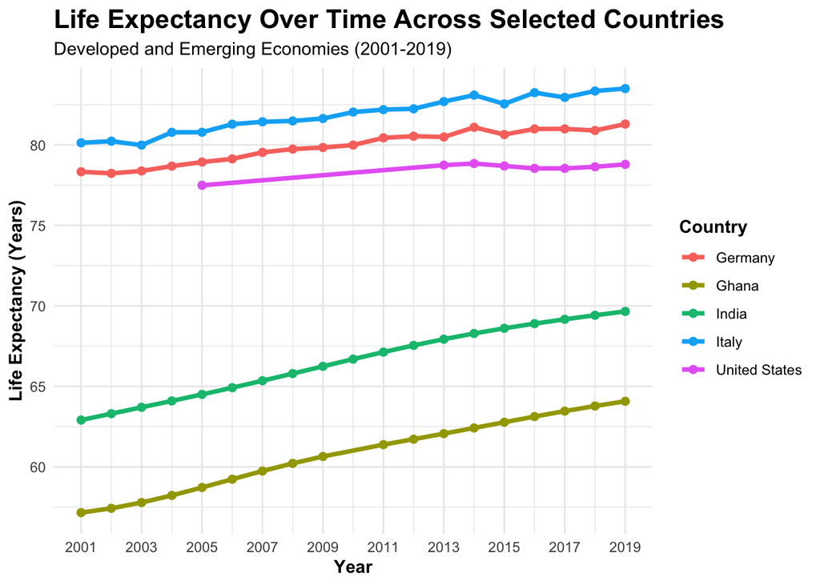

```r
# Plot
ggplot(
  life_plot,
  aes(
    x = year,
    y = life_exp,
    color = country,
    group = country
  )
) +
  geom_line(linewidth = 1.3) +
  geom_point(size = 2) +
  labs(
    title = "Life Expectancy Over Time Across Selected Countries",
    subtitle = "Developed and Emerging Economies (2001-2019)",
    x = "Year",
    y = "Life Expectancy (Years)",
    color = "Country"
  ) +
  scale_x_continuous(
    breaks = seq(
      min(life_plot$year, na.rm = TRUE),
      max(life_plot$year, na.rm = TRUE),
      by = 2
    )
  ) +
  theme_minimal() +
  theme(
    plot.title = element_text(
      face = "bold",
      size = 16
    ),
    plot.subtitle = element_text(
      size = 11
    ),
    axis.title = element_text(
      face = "bold"
    ),
    legend.position = "right",
    legend.title = element_text(
      face = "bold"
    )
  )
```

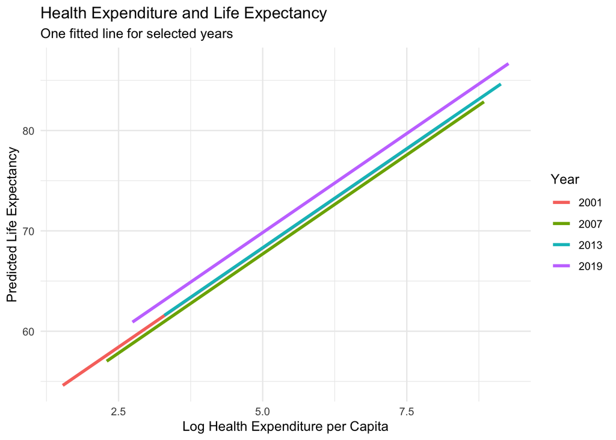

```r
# VEDI SE METTERLO
selected_years <- c(
  2001,
  2007,
  2013,
  2019
)

pdata_plot <- as.data.frame(pdata) %>%
  filter(year %in% selected_years)

mod_health_year <- lm(
  life_exp ~ log_health_pc + factor(year),
  data = pdata_plot
)

pdata_plot$yhat_health <- predict(
  mod_health_year,
  newdata = pdata_plot
)

ggplot(
  pdata_plot,
  aes(
    x = log_health_pc,
    y = yhat_health,
    colour = factor(year),
    group = year
  )
) +
  geom_line(linewidth = 1.2) +
  labs(
    title = "Health Expenditure and Life Expectancy",
    subtitle = "One fitted line for selected years",
    x = "Log Health Expenditure per Capita",
    y = "Predicted Life Expectancy",
    colour = "Year"
  ) +
  theme_minimal()
```

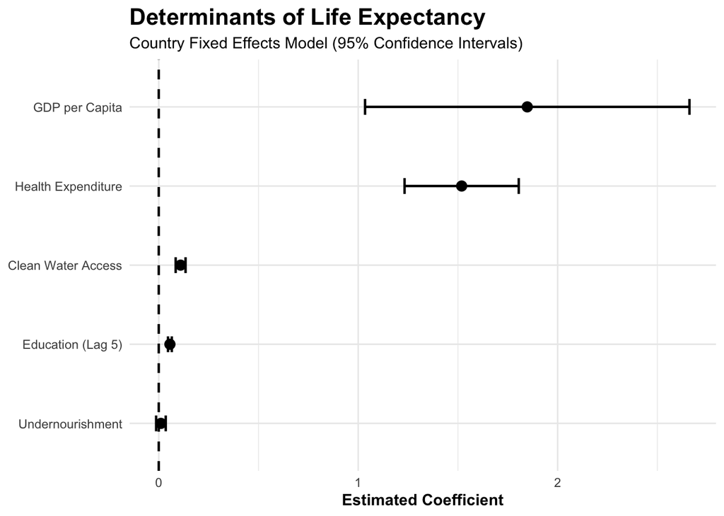

```r
# COEFFICIENT PLOT - FIXED EFFECTS MODEL
library(broom)

# Extract coefficients
coef_df <- tidy(model_fe)

# Remove intercept if present
coef_df <- coef_df %>%
  filter(term != "(Intercept)")

# Rename variables manually
coef_df$Variable <- coef_df$term

coef_df$Variable[coef_df$term == "log_health_pc"] <- "Health Expenditure"
coef_df$Variable[coef_df$term == "education_lag5"] <- "Education (Lag 5)"
coef_df$Variable[coef_df$term == "log_gdp_pc"] <- "GDP per Capita"
coef_df$Variable[coef_df$term == "undernourishment"] <- "Undernourishment"
coef_df$Variable[coef_df$term == "clean_water"] <- "Clean Water Access"

# Plot
ggplot(
  coef_df,
  aes(
    x = estimate,
    y = reorder(Variable, estimate)
  )
) +
  geom_vline(
    xintercept = 0,
    linetype = "dashed",
    linewidth = 0.8
  ) +
  geom_point(
    size = 3
  ) +
  geom_errorbarh(
    aes(
      xmin = estimate - 1.96 * std.error,
      xmax = estimate + 1.96 * std.error
    ),
    height = 0.20,
    linewidth = 0.8
  ) +
  labs(
    title = "Determinants of Life Expectancy",
    subtitle = "Country Fixed Effects Model (95% Confidence Intervals)",
    x = "Estimated Coefficient",
    y = NULL
  ) +
  theme_minimal() +
  theme(
    plot.title = element_text(
      face = "bold",
      size = 16
    ),
    plot.subtitle = element_text(
      size = 11
    ),
    axis.title = element_text(
      face = "bold"
    )
  )
```

## 7. Conclusion

This study examined the relationship between health expenditure, education, and life expectancy using a panel dataset of 105 countries and 1,565 country-year observations.

The results provide evidence that both health expenditure and education are positively associated with life expectancy. Health expenditure shows a strong positive relationship in both OLS and Country Fixed Effects models, although this relationship becomes insignificant once year fixed effects are introduced. In contrast, education remains positively associated with life expectancy across all specifications, making it the most robust finding of the analysis. The interaction analysis further suggests that the effectiveness of health expenditure may depend on a country’s level of economic development, with stronger associations found in poorer countries.

### Policy Implications

The findings highlight the importance of investing in both healthcare systems and education. While healthcare expenditure contributes to better health outcomes, education appears to generate broad and persistent benefits that extend beyond the healthcare sector. The results also suggest that health investments may be particularly effective in developing countries, where basic healthcare services and infrastructure remain limited.

### Study Limitations

Our analysis is subject to several methodological limitations that must be critically assessed.

**External Validity:** While the large panel of 105 countries improves the generalizability of our findings, the estimated coefficients represent average global associations. The precise impact of health expenditure and education on life expectancy may differ substantially across specific institutional, cultural, or historical contexts not captured by this global average. Therefore, these results should be interpreted as robust associations rather than definitive, universally applicable causal effects.

## 8. References

- Nixon, J., & Ulmann, P. (2006). *The relationship between health care expenditure and health outcomes*. European Journal of Health Economics, 7(1), 7–18.
- Cutler, D. M., & Lleras-Muney, A. (2006). *Education and Health: Evaluating Theories and Evidence*. NBER Working Paper No. 12352.

## 9. Methodological Diagnostics [SUPPLEMENTARY]

To further investigate the diagnostic tests reported in the main analysis (specifically the Breusch-Pagan test for heteroskedasticity, which yielded a highly significant $p$-value $< 2.2e-16$), we provide a supplementary visual inspection of the residuals. This visualization confirms the necessity of employing heteroskedasticity-robust standard errors (`HC1`) throughout the empirical execution.

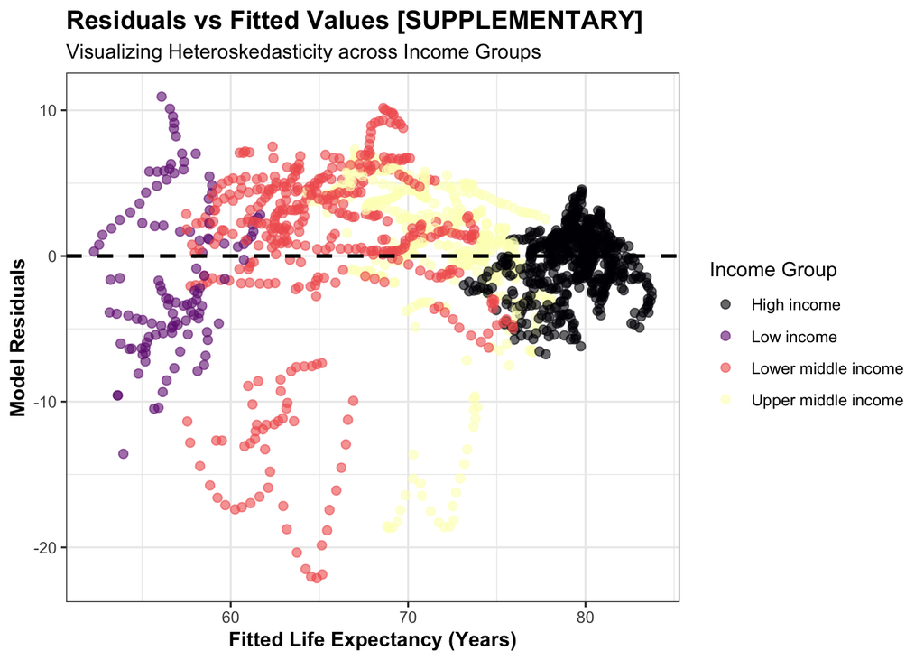

```r
# TITLE [SUPPLEMENTARY]
# SUPPLEMENTARY ANALYSIS: Residual Diagnostics and Heteroskedasticity Visualization

library(ggplot2)
library(viridis)

# Extract complete cases used in the OLS model to ensure vector lengths match
supp_data <- df_clean %>%
  filter(complete.cases(life_exp, log_health_pc, education_lag5, log_gdp_pc, undernourishment, clean_water))

# Compute fitted values and residuals from the primary OLS model
supp_data$fitted_values <- predict(model_ols_both)
supp_data$residuals <- resid(model_ols_both)

# Plot Residuals vs Fitted Values to visualize variance spread
ggplot(supp_data, aes(x = fitted_values, y = residuals, color = income_group)) +
  geom_point(alpha = 0.6, size = 2) +
  geom_hline(yintercept = 0, linetype = "dashed", color = "black", linewidth = 1) +
  scale_color_viridis_d(option = "magma") +
  theme_bw() +
  labs(
    title = "Residuals vs Fitted Values [SUPPLEMENTARY]",
    subtitle = "Visualizing Heteroskedasticity across Income Groups",
    x = "Fitted Life Expectancy (Years)",
    y = "Model Residuals",
    color = "Income Group"
  ) +
  theme(
    plot.title = element_text(face = "bold", size = 14),
    axis.title = element_text(face = "bold")
  )
```

[output not shown]